# R程式整理

### 基本函數運用

#### 1.

Use seq() and rep() to write codes for the following questions:  
(a) Construct a vector as the same output as:  
1 2 3 4 5 1 2 3 4 5 1 2 3 4 5 1 2 3 4 5 1 2 3 4 5  
## b<- rep(c(1:5),5)(創建向量b)  
(b) Construct a vector as the same output as:  
0 0 0 0 0 1 1 1 1 1 2 2 2 2 2 3 3 3 3 3 4 4 4 4 4  
## c<-rep(seq(0,4),rep(5,5))(創建向量)c  
(c) Construct a vector as the same output as:  
1 2 3 4 5 2 3 4 5 6 3 4 5 6 7 4 5 6 7 8 5 6 7 8 9  
## a<-c(b+c)(向量a是向量b加向量c)  
(d) Let more.color be defined as follows:more.colors->c(“red”,“yellow”,“blue”,“green”,“magenta”,“cyan”)  
Use more.color, seq(), and rep() to create a vector as follows:“red” “yellow” “blue” “yellow” “blue” “green” “blue” “green” “magenta” “green” “magenta” “cyan”.Give the name “color.vec” to this created vector.  
## more.colors<-c(“red”,“yellow”,“blue”,“green”,“magenta”,“cyan”)  
## color.vec<-c(more.colors[c(seq(1,3),seq(2,4),seq(3,5),seq(4,6))])(利用索引創建color.vec向量)  
## color.vec  
(e) According to (d), how many colors in color.vec?  
## unique(color.vec)共6種  
(f) According to (d), how many times does each color appear in color.vec?  
## table(color.vec) answer:blue 3 cyan 1 green 3 magenta 2 red 1 yellow 2  
(g) Rearrange the order in color.vec by letting the first letter from z to a.  
## sort(color.vec,decreasing=TRUE)反向排序

#### 2.

Use seq(), rep(), and vector calculation in R to write codes for the following questions.  
(a) Calculate the values of $\Sigma_{j=1}^n j^2$ when n = 200, 400, 600, 800.  
## n$_1$<-200  
a<-seq(1:n$_1$)  
b$_1$_200<-sum(a$\cdot$a)  
b$_1$_200  
#2686700以此類推  
(b) Calculate the values of n(n+1)(2n+1)/6 when n = 200, 400, 600, 800.  
## n$_2$<-200  
b$_2$_200<-n$_2$(n$_2$+1)(2n$_2$+1)/6  
b$_2$_200  
#2686700以此類推  
(c) Check if the values of (a) and (b) are the same.  
## all.equal(b$_1$_200,b$_2$_200)  
#TRUE以此類推

#### 3.

score0 <- c(81.2, 89.6, 64.2, 91.3, 77.4, 84.5, NA, 91.7, 63.5, 84.8, NA, 87.8, 87.9, 80.9, 74.8, 64.3, 78.7, 91.3, 76.9, 74.9, 87.6, 88.4)  
(a) Typing mean(score0) and max(score0), what results do you get?  
# NA and NA  
(b) How to modify mean() and max() so that you can get the numeric answers?  
## mean(score0,na.rm=TRUE) and max(score0,na.rm=TRUE)  
(c) Delete NA from the vector score0 and assign the name score1 to the new vector. What do you get if you type mean(score1) and max(score1)? Are the answers the same as those in (b)?  
## score1<-na.omit(score0)  
mean(score1) #81.085  
max(score1) #91.7  
Yes.They are same.  
(d) If I obtain two scores, 67.2 and 89.5, try to change the values in score0 from NA to 67.2 and 89.5, and assign the name score2 to the new vector.  
## a<-which(is.na(score0))  
score2<-score0  
score2[a]<-c(67.2,89.5)  
score2  
(e) What do you get if you type mean(score2) and max(score2)?  
## mean(score2) #80.83636  
max(score2) #91.7

### 矩陣運用

#### 1.

Rolling two fair dices, evaluate the total number that all possible outcomes occur at least once. The events are as follows, and each row has two outcomes of dices.  
two.dice <- matrix( c(3, 5, 5, 4, 4, 3, 4, 5, 5, 2, 3, 2, 6, 6, 6,  
3, 6, 2, 1, 2, 5, 6, 1, 5, 6, 1, 3, 6, 6, 3,  
5, 3, 3, 5, 3, 3, 4, 2, 1, 4, 3, 1, 5, 1, 6,  
4, 5, 5, 3, 5, 2, 2, 1, 2, 2, 6, 1, 3, 4, 5,  
6, 4, 3, 3, 6, 1, 2, 1, 4, 5, 1, 1, 2, 3, 6,  
5, 6, 5, 3, 1, 4, 1, 5, 2, 2, 6, 3, 2, 3, 1,  
5, 1, 2, 5, 1, 1, 1, 3, 1, 3, 4, 1, 6, 5, 1,  
5, 6, 6, 5, 5, 2, 4, 1, 3, 5, 2, 1, 1, 1, 1), ncol = 2)  
##  
dicesum<-matrix(two.dice[,1]+two.dice[,2])  
n<-length(dicesum)  
number<-c()  
for (i in 1:n){  
if (dicesum[i] %in% number==FALSE){  
number<-c(number,dicesum[i])  
if (length(number)==11){  
break  
}  
}  
}  
i  
#43

### for迴圈

#### 1.

Let U$_1$,……, U$_k$ be from a uniform(0,1). Define  
N=max{n:$\prod^n_{i=1} U_i>10^{-8}$}  
What is the value of N if you use the following sequence? U <- c(0.89, 0.03, 0.52, 0.41, 0.09, 0.37, 0.71, 0.29, 0.01, 0.92,0.53, 0.14, 0.64, 0.94, 0.89, 0.19, 0.33, 0.31, 0.24, 0.15)  
##  
U <- c(0.89, 0.03, 0.52, 0.41, 0.09, 0.37, 0.71, 0.29, 0.01, 0.92,0.53, 0.14, 0.64, 0.94, 0.89, 0.19, 0.33, 0.31, 0.24, 0.15)  
n<-length(U)  
b<-c()  
for (i in 1:n){  
x<-prod(U[1:i])  
if (x>10^(-8)) {  
b<-c(b,i)  
}  
}  
max(b)  
#15

#### 2.

Collect students’ scores of math and English as follows:  
Math <- c(79, 61, 76, 40, 51, 98, 48, 34, 54, 51, 45, 61, 75, 42, 32,61, 56, 82, 22, 33, 19, 60, 91, 49, 44)  
English <- c(87, 54, 96, 63, 58, 75, 60, 74, 46, 94, 57, 69, 69, 55, 79,94, 72, 86, 85, 56, 62, 77, 78, 62, 56)  
(a) Construct a matrix with two columns to collect these scores. The first column is for math and the second column is for English. Assign the names for the columns as “Math” and “English”, respectively,and assign the ID numbers for the rows from 1 to the total number of the students. Assign the name tothe matrix as “scores”.  
##  
Math<-c(79,61,76,40,51,98,48,34,54,51,45,61,75,42,32,61,56,82,22,33,19,60,91,49,44)  
English<-c(87,54,96,63,58,75,60,74,46,94,57,69,69,55,79,94,72,86,85,56,62,77,78,62,56)  
scores<-cbind(Math,English)  
colnames(scores)<-c(“Math”,“English”)  
a<-length(Math)  
rownames(scores)<-c(1:a)  
scores  
(b) Classify the students by the scores. Define the student passes the class if the score is greater or equal to 60, and the student gets a fail if the score is less than 60. Summarize the number of each of the following event:  
A: Math ≥ 60 and English ≥ 60;  
B: Math ≥ 60 and English < 60;  
C: Math < 60 and English ≥ 60;  
D: Math < 60 and English < 60.  
##  
A<-0,B<-0,C<-0,D<-0  
for (i in 1:a){  
if (scores[i,1]>=60 & scores[i,2]>=60){  
A<-A+1  
}  
else if (scores[i,1]>=60 & scores[i,2]<60){  
B<-B+1  
}  
else if (scores[i,1]<60 & scores[i,2]>=60){  
C<-C+1  
}  
else if (scores[i,1]<60 & scores[i,2]<60){  
D<-D+1  
}  
}  
A # 9  
B # 1  
C # 9  
D # 6  
(c) Provide the students’ ID numbers in each category (A, B, C, D).  
##  
A<-c(),B<-c(),C<-c(),D<-c()  
for (i in 1:a){  
if (scores[i,1]>=60 & scores[i,2]>=60){  
A<-c(A,i)  
}  
else if (scores[i,1]>=60 & scores[i,2]<60){  
B<-c(B,i)  
}  
else if (scores[i,1]<60 & scores[i,2]>=60){  
C<-c(C,i)  
}  
else if (scores[i,1]<60 & scores[i,2]<60){  
D<-c(D,i)  
}  
}  
A # 1 3 6 12 13 16 18 22 23  
B # 2  
C # 4 7 8 10 15 17 19 21 24  
D # 5 9 11 14 20 25

#### 3.

When you enter a vector including {5, 10, 11, 1, 0, 3, 8, 10, 4, 0, 1, 6, 7, 10, 7, 0}, treat 0 as a missing value.  
Delete all missing values and evaluate the following questions:  
(1) Sum of the values in the vector;  
(2) The length of the input vector;  
(3) The average of the values in the vector;  
(4) The number of odd values in the vector;  
(5) The number of 10 in the vector;  
(6) The maximum of the values in the vector.  
Apply the code to the vector {7, 5, 0, 1, 2, 7, 1, 10, 5, 0, 3, 7, 2, 3, 3} and print the results from (1) to (6).  
##  
data1<-c(7, 5, 0, 1, 2, 7, 1, 10, 5, 0, 3, 7, 2, 3, 3)  
c=which(data1==0)  
data1=data1[-c]  
odd1<-c()  
for (i in data1){  
if (i%%2!=0){  
odd1<-c(odd1,i)  
}  
}  
d=which(data1==10)  
cat(“(1) Sum:”,sum(data1),“(2) length:”,length(data1),“(3) Average:”,mean(data1),“(4) # of odd:”,length(odd1),“(5) # of 10:”,length(d),“(6) Max:”,max(data1))

### R Markdown幾率分配圖

Draw the pdf (or pmf) of each distribution in the questionbefore. Write codes and use all control argument in plot(…) and par(…) to show the following plots.

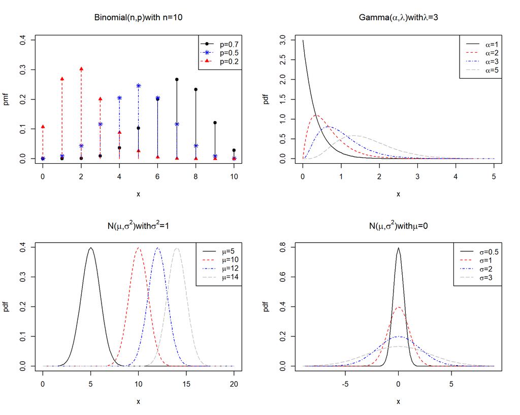

```r
 par(mfrow=c(2,2))
##1
 plot(c(0:10),dbinom(c(0:10),10,0.7),xlim=c(0,10),ylim=c(0.0,0.4),pch=19,col="black",main=expression(paste("Binomial(n,p)with n=10")),xlab="x",ylab="pmf")
 points(c(0:10),dbinom(c(0:10),10,0.5),xlim=c(0,10),ylim=c(0.0,0.4),pch=8,col="blue")
 points(c(0:10),dbinom(c(0:10),10,0.2),xlim=c(0,10),ylim=c(0.0,0.4),pch=17,col="red")
 segments(x0=c(0:10),y0=0.0,x1=c(0:10),y1=dbinom(c(0:10),10,0.7),xlim=c(0,10),ylim=c(0.0,0.4),lty=1,col="black")
 segments(x0=c(0:10),y0=0.0,x1=c(0:10),y1=dbinom(c(0:10),10,0.5),xlim=c(0,10),ylim=c(0.0,0.4),lty=4,col="blue")
 segments(x0=c(0:10),y0=0.0,x1=c(0:10),y1=dbinom(c(0:10),10,0.2),xlim=c(0,10),ylim=c(0.0,0.4),lty=2,col="red")
 legend("topright", legend = c("p=0.7", "p=0.5", "p=0.2"),
 pch = c(19, 8, 17), lty = c(1, 4, 2),
 col = c("black", "blue","red"), text.col = c(1,1,1))

##2
 curve(dgamma(x,1,3), 0, 5,ylim=c(0.0,3.0),lty=1,col="black",main=expression(paste("Gamma(",alpha,",", lambda,")with",lambda,"=3")),ylab="pdf")
 curve(dgamma(x,2,3), 0, 5,ylim=c(0.0,3.0),add=TRUE,lty=2,col="red")
 curve(dgamma(x,3,3), 0, 5,ylim=c(0.0,3.0),add=TRUE,lty=4,col="blue")
 curve(dgamma(x,5,3), 0, 5,ylim=c(0.0,3.0),add=TRUE,lty=5,col="grey")
 legend("topright", legend = c(expression(paste(alpha,"=1")),expression(paste(alpha,"=2")),expression(paste(alpha,"=3")),expression(paste(alpha,"=5"))),
lty = c(1,2,4,5),
 col = c("black", "red","blue","grey"), text.col = c(1,1,1,1))

##3
 curve(dnorm(x,5,sd=1),0,20, col="black",lty=1,main=expression(paste("N(",mu,",", sigma^2,")with",sigma^2,"=1")),ylab="pdf")
 curve(dnorm(x,10,sd=1),0,20, col="red", add=TRUE,lty=2)
 curve(dnorm(x,12,sd=1),0,20, col="blue", add=TRUE,lty=4)
 curve(dnorm(x,14,sd=1),0,20, col="grey", add=TRUE,lty=5)
 legend("topright", legend = c(expression(paste(mu,"=5")),expression(paste(mu,"=10")),expression(paste(mu,"=12")),expression(paste(mu,"=14"))),
lty = c(1,2,4,5),
 col = c("black", "red","blue","grey"), text.col = c(1,1,1,1))

##4
 curve(dnorm(x,0,sd=0.5),-9,9, col="black",lty=1,main=expression(paste("N(",mu,",", sigma^2,")with",mu,"=0")),ylab="pdf")
 curve(dnorm(x,0,sd=1),-9,9, col="red", add=TRUE,lty=2)
 curve(dnorm(x,0,sd=2),-9,9, col="blue", add=TRUE,lty=4)
 curve(dnorm(x,0,sd=3),-9,9, col="grey", add=TRUE,lty=5)
 legend("topright", legend = c(expression(paste(sigma,"=0.5")),expression(paste(sigma,"=1")),expression(paste(sigma,"=2")),expression(paste(sigma,"=3"))),
lty = c(1,2,4,5),
 col = c("black", "red","blue","grey"), text.col = c(1,1,1,1))
```